# Udacity Data Analyst Nanodegree - Project 5: `Pisa2012` Results Analysis -

# Exploratory and Explanatory Data Visualisation, by Dyke Ferber

## `Explanatory Data Analysis Slidedeck`

### III. What we will focus on in this notebook

### The `PISA 2012` dataset: A brief introduction

The PISA survey (Programme for International Student Assessment) is an international survey dedicated to compare the level of educational fitness of school students around the age of 15 years that are about to graduate. Therein, PISA does not aim to assess theoretical knowledge in different domains like biology, chemistry and languages, however asks how well the teenagers can apply what they have learned throughout their school time to real-world situations.  
The dataset we used here contains the full results from 2012. It holds 485489 entries (observations) and 635 features (variables). It is therefore an extraordinarily large dataset and we will therefore reduce it in order to answer some key questions in this dataset.

While many other Udacity Students followed the most obvious question, wheter the amount of time and effort spend learning correlates to overall good test results, I herein want to ask 2 key questions. 1: wether the financial situation at home has anything to do with the outcome in the test statistics, and 2. if students that regularly skip school perform worse (I almost never skipped lessons and wonder if I should have done this in order to sometimes evade some boring hours without sacrifying my test performance) ...

## Research Questions in this Notebook:

`1. Is there a potential impact of the financial situation on a students test outcome or vice versa ?`  
`2. Is beeing late for school and skipping school lessons bad for your test performance ?`  
`(3. Additional) What countries perform best ? How is Germany performing ? Is it as bad as we think ?`

## Research question 1:

`1. Is there a potential impact of the financial situation on a students test outcome or vice versa ?`

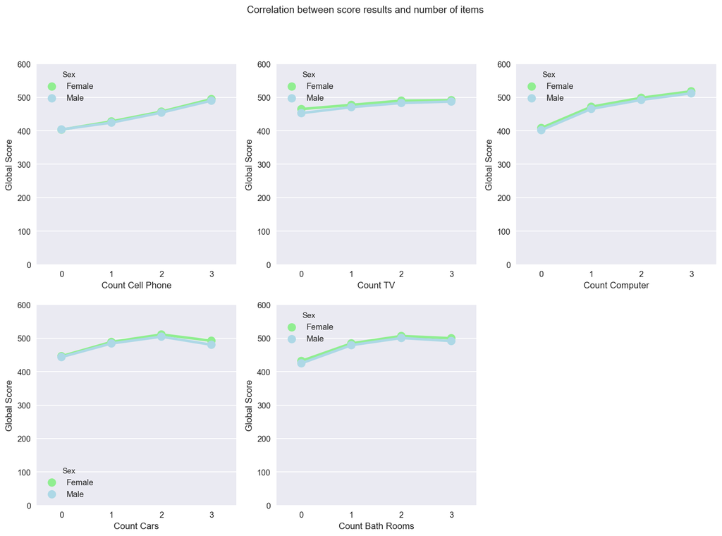

```python
# Now use a lineplot (sns.pointplot) to investigate the relationship between the number of luxury items at home and a students PISA 2012 test performance.

fig = plt.figure(figsize=(15,10))

nrows = 2
ncols = 3
axes = []

for idx, col in enumerate(counts[:-1]):
    axes.append(fig.add_subplot(nrows, ncols, idx+1))
    sns.pointplot(data=pisa, x=col, y="global_score", hue="Sex", palette=["lightgreen", "lightblue"]);
    if col == "Count_Books":
        plt.xticks(rotation = 10);
    plt.ylim([0, 600]);
    plt.xlabel(col.replace("_", " "))
    plt.ylabel("Global Score")
plt.suptitle("Correlation between score results and number of items");
```

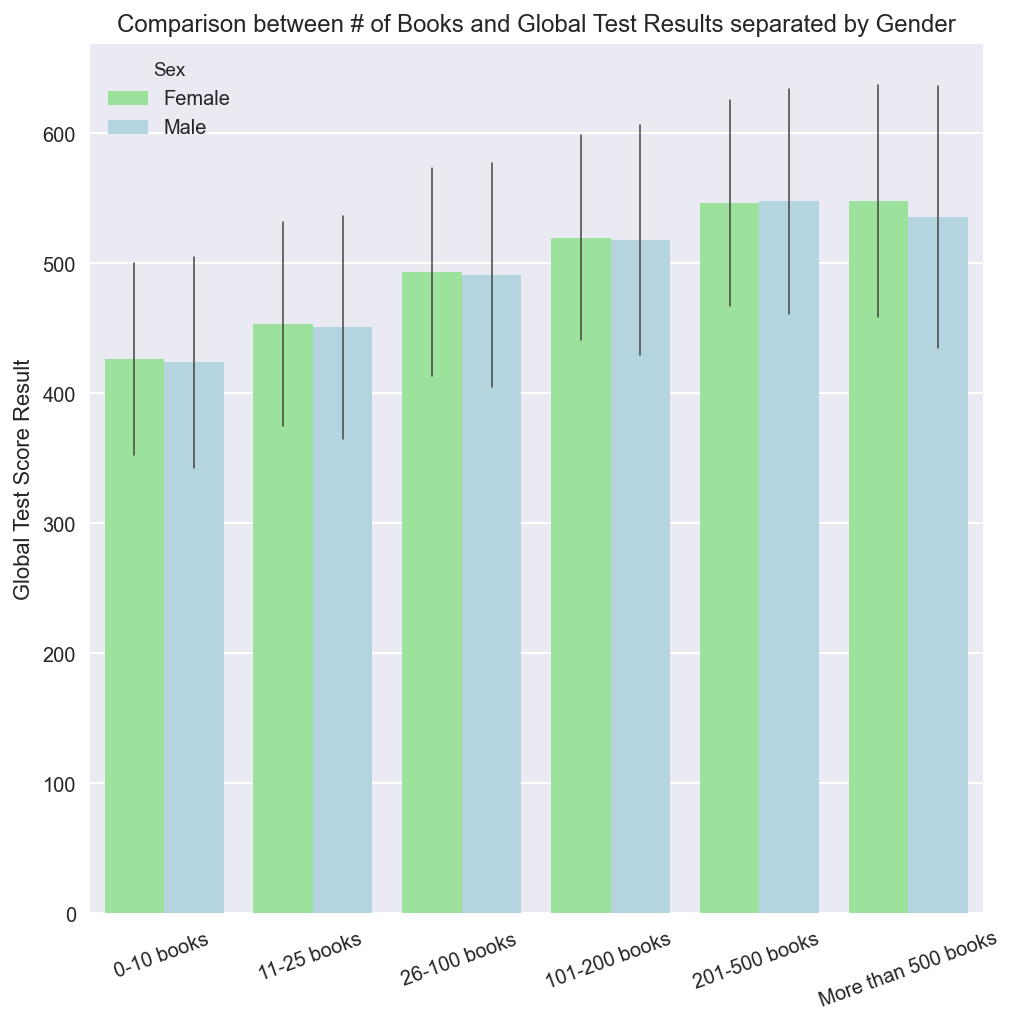

```python
# repeat the same in a barchart for the number of books that are at home

plt.figure(figsize=(8,8))
sns.barplot(data=pisa, x="Count_Books", y="global_score", palette=["lightgreen", "lightblue"], ci="sd", hue="Sex", errwidth = 0.75);
plt.xlabel(None);
plt.xticks(rotation=20)
plt.ylabel("Global Test Score Result");
plt.title("Comparison between # of Books and Global Test Results separated by Gender");
plt.savefig("Books_Global_Scores.png")
```

## Research question 2:

`2. Is beeing late for school and skipping school lessons bad for your test performance ?`

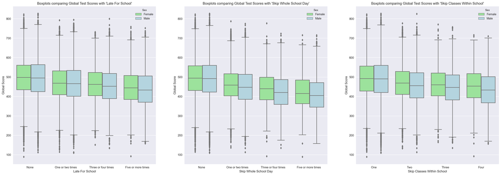

```python
truancy = ['Late_For_School', 'Skip_Whole_School_Day',
           'Skip_Classes_Within_School']

axes = []
nrows = 1
ncols = 3

fig = plt.figure(figsize=(30,10))

for idx, col in enumerate(truancy):
    axes.append(fig.add_subplot(nrows, ncols, idx+1))
    plt.title("Boxplots comparing Global Test Scores with '{}'".format(col.replace("_", " ")))
    sns.boxplot(data=pisa, x=col, y="global_score", hue="Sex", palette=["lightgreen", "lightblue"])
    plt.xlabel(col.replace("_", " "))
    plt.ylabel("Global Score")
    if idx == 2:
        plt.xticks([0,1,2,3], ["One", "Two", "Three", "Four"])
```

> `Key findings` The three boxplots above show the relationship between kids beeing late for school, skipping whole school days a couple of times or classes at all with their global PISA test results. Not surprisingly, independently of gender, the more often kids are late for school or the more school days they skip, the worse their results get. Additionally we can see that for almost any category, girls still fall into achieving a better score than boys (see the horizontal line for median). This trend is even more stricking among all three plots for those who most frequently are late of miss school most often.

## Research question 3:

`(3. Additional) What countries perform best ? How is Germany performing ? Is it as bad as we think ?`

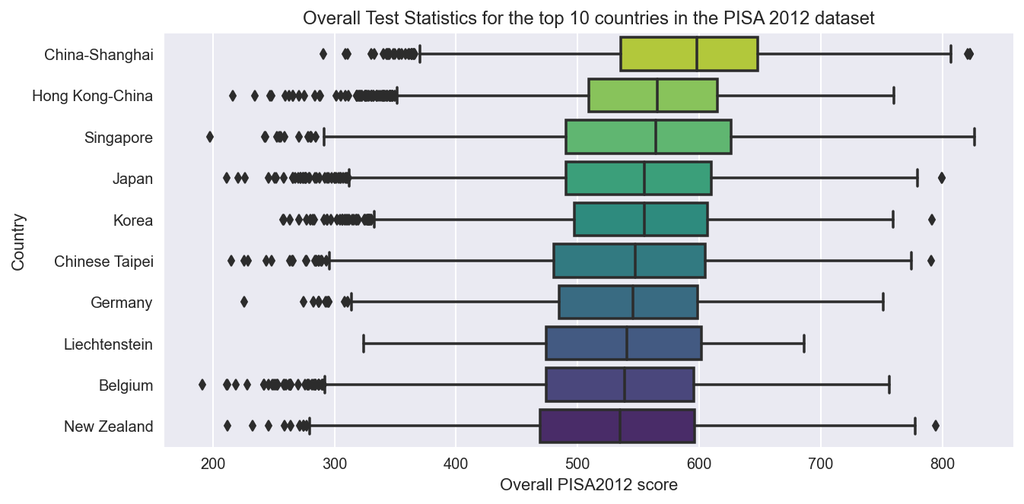

```python
# visualise the top 10 countries

plt.figure(figsize=(10,5));

plt.title("Overall Test Statistics for the top 10 countries in the PISA 2012 dataset")
sns.boxplot(data=top10, y="Country_Code", x="global_score", order=top10_ranking, palette="viridis_r");
plt.ylabel("Country")
plt.xlabel("Overall PISA2012 score")
plt.savefig("Top_10_countries.png")
```

> `Key findings` Luckily, Germany made it into the top10, even as number one country from Europe, followed by Liechtenstein and Belgium (our close neighbours). The top performing countries however (not unexpectedly) are from the asian region.

## Summary

> **In this notebook we investigated the role of possessing items like a lot of cars, books etc at home on the overall score kids achieve in the PISA 2012 survey. We found out that**
> 1. ... the better the financial situation at home appears, reflected by the number of cars they have in their garage or the number of bathrooms in their houses, the more likely it is that this correlates with a better performance in the test. This is an important insight, because it might still show that in the year 2012 educational fitness is still a matter of money. Some third world countries performed especially bad in this survey (data not shown), while highly developped countries like Germany and Taiwan perform overall better ...

## Summary

> 1. ... Especially modern media like the access to computers and the internet appears to be quite important on the test results (cave: we did not perform any statistics, so we should not conclude a direction of the correlation, but I just do it here intuitively), while number of cars or bath rooms is most likely to some kind of bias (bystander effect) reflecting the overall economical situation at home. Therefore, guaranteeing access to a computer seems to be important in the future to provide same chances for everyone irrespective of the financial situation at home.